# High-volume Scatterplots Revisited

Peter von Rohr

2019-01-15

## Introduction

High-volume scatterplot are scatterplots with many points. This typically leads to overplotting and when saving the plots to files using vector-based devices such as `pdf()` or `postscript` result files are very large.

A first solution to this problem is to use raster-based graphics devices such as `png()` or `jpeg()`. But those devices require X11-library support to be installed. On an ubuntu system this support can be installed using the package `xorg-dev`.

In what follows alternative ways to overcome the problem of high-volume scatterplots when the native raster-based devices such as `png()` and `jpeg()` are not available are described.

## Alternative Solutions

This section contains a few alternative solutions

### smoothScatter

Instead of plotting each point in a high-volumn scatterplot, a smoothed version of the plot is drawn using a 2D kernel density estimate. This can be done in the function `graphics::smoothScatter()` which is available in base-r. This approach is described in more detail under https://www.stat.ubc.ca/~jenny/STAT545A/block91_latticeGraphics.html.

### grid.raster

In case we are able to represent the scatterplot data in a matrix, we can use `grid.raster()` to draw a rasterized image of the plot. For more details, please have a look at https://journal.r-project.org/archive/2011-1/RJournal_2011-1_Murrell.pdf

### gglot2

Instead of saving the plots as raster-based images, we can use `ggplot2` for plottting and save the plot as R-objects using the `save()` function. The saved R-objects can be re-loaded on a different system with support for `png()` and `jpeg()` and viewed on this second system.

## Numerical Example

In this section we want to investigate the file sizes of the different proposed approaches. For this we first create a random dataset and create from this a scatterplot and save those plots to files.

```r
n_nr_obs <- 10^5
n_inter <- 3.24
n_slope <- 0.7
x <- runif(n_nr_obs)
y <- n_inter + n_slope * x + rnorm(n_nr_obs)
tbl_plot_data <- tibble::tibble(x = x, y = y)
```

The produced scatter plots that will be saved in files all look more or less as follows

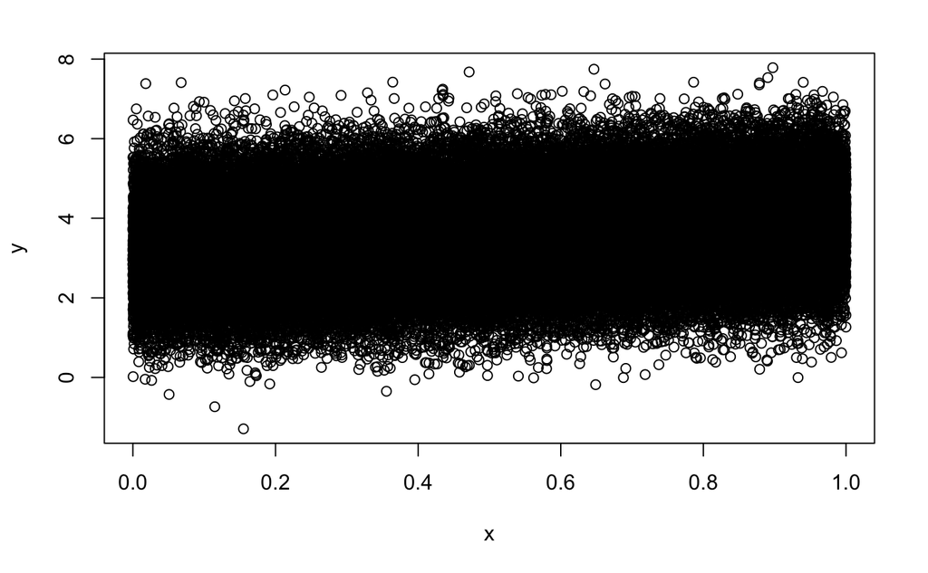

```r
plot(x, y)
```

The above shown scatter plot contains large sections of over-plotting. A smoothed scatter plot might give more information in all areas of the plot.

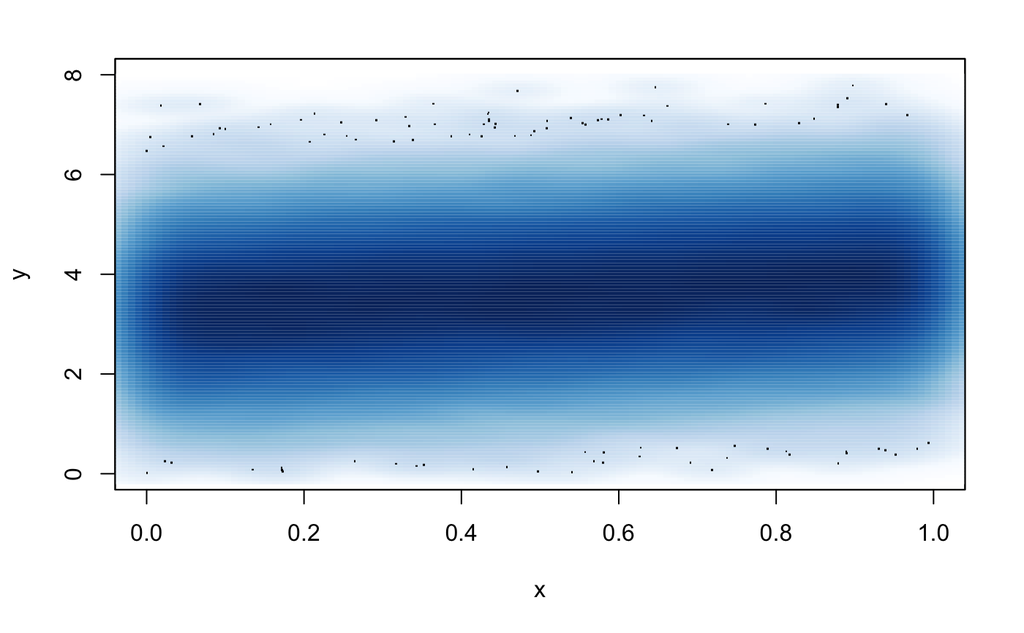

```r
smoothScatter(y ~ x, xlim = c(0,1), ylim = c(0, 8))
```

### pdf

```r
s_out_path_vec <- "Rvecplot.pdf"
pdf(s_out_path_vec)
plot(x, y)
dev.off()
```

```r
n_vec_filesize <- file.info(s_out_path_vec)$size
```

### png

The lower bound of the file size or the target value is reached with an ordinary `png`-plot

```r
s_out_path_png <- "Rpngplot.png"
png(s_out_path_png)
plot(x, y)
dev.off()
```

```r
n_png_filesize <- file.info(s_out_path_png)$size
```

### smoothScatter

The `graphics` package from r-base contains the function `smoothScatter()` which shades the plane according to a 2D kernel density estimate.

```r
s_out_path_smooth <- "Rsmoothplot.pdf"
pdf(s_out_path_smooth)
#smoothScatter(y ~ x, colramp = colorRampPalette(c("white", blues9)), xlim = c(0,1), ylim = c(0, 8))
smoothScatter(y ~ x, xlim = c(0,1), ylim = c(0, 8))
dev.off()
```

```r
n_smooth_filesize <- file.info(s_out_path_smooth)$size
```

### ggplot2

This approach is different in the sense that it does not store the graphics files, but it stores the graphics objects. This can only be done with `ggplot2`.

```r
require(ggplot2)
s_put_path_plot_obj <- "Rplotobj.rda"
p <- ggplot(tbl_plot_data, aes(x, y)) + geom_point()
save(p, file = s_put_path_plot_obj)
n_ggplot_filesize <- file.info(s_put_path_plot_obj)$size
```

On a different machine the plot is loaded again and the plotted.

```r
s_out_path_ggplot <- "Rggplot.png"
load(s_put_path_plot_obj)
ggsave(s_out_path_ggplot, plot = p, width = 4, height = 4)
n_png_ggplot_filesize <- file.info(s_out_path_ggplot)$size
```

### Resulting Filesizes

The table below gives an overview of the file sizes

| Filename | Method | File Size (in KB) |
| --- | --- | --- |
| Rvecplot.pdf | pdf | 699.95 |
| Rpngplot.png | png | 64.90 |
| Rsmoothplot.pdf | smooth | 86.37 |
| Rplotobj.rda | ggplot2obj | 1286.01 |
| Rggplot.png | ggsave | 128.55 |

## Clean Up

All the plot files are removed.

```r
file.remove(tbl_file_size$Filename)
```

```
[1] TRUE TRUE TRUE TRUE TRUE
```